# Capstone Project: Exploration

## Machine Learning Engineer Nanodegree

### Manceñido Agustín, 2019

[figure not shown]

> **Notes:**
> - For the bechmarks models used as baseline for this project, please refer to the [Capstone benchmarks](https://machinelearningmastery.com/persistence-time-series-forecasting-with-python/) file.
> - For the complete final model and results, please refer to the [Capstone exploration](https://machinelearningmastery.com/persistence-time-series-forecasting-with-python/) file.

### Contents

- Step 00: Import libraries & Load dataset
- Step 01: Functions
- Step 02: Feature Engineering
- Step 03: Explore Dataset
- Step 04: Explore Pricing
- Step 05: Explore sellers
- Step 06: Explore Position
- Step 07: Explore Title (text processing)
- Step 08: Label Encoder
- Step 09: Transforming Skewed Data
- Step 10: Correlation in the dataset
- Step 11: Feature extraction

## Step 0: Import libraries & Load dataset

```python
## Import libraries

# General
import numpy as np
import pandas as pd
import re
import string
from dateutil.relativedelta import relativedelta

# Progress
from ipywidgets import IntProgress
from tqdm import tqdm
tqdm.pandas()

# sklearn
from sklearn.preprocessing import MinMaxScaler
from sklearn.feature_extraction.text import TfidfVectorizer
from sklearn.preprocessing import LabelEncoder

# keras
from keras.preprocessing.text import Tokenizer

# WordCloud
from wordcloud import WordCloud
from collections import Counter

# Display
from IPython.display import display_html

# Plot libraries
import seaborn as sns
from plotly.offline import init_notebook_mode, iplot
import plotly.graph_objs as go
import matplotlib.pyplot as plt
import plotly.plotly as py
from plotly import tools
init_notebook_mode(connected=True)

# Word libraries
import nltk
from nltk.corpus import stopwords
from nltk.tokenize import word_tokenize, sent_tokenize
nltk.download('stopwords')
nltk.download('punkt')
```

```
True
```

```python
# Load dataset
try:
    data = pd.read_csv("database.csv")
    data.drop(['meliid'], axis = 1, inplace = True)
    print("Dataset has {} samples with {} features each.".format(*data.shape))
except:
    print("Dataset could not be loaded. Is the dataset missing?")
```

```
Dataset has 795295 samples with 8 features each.
```

```python
# Display dataset sample and show date range
print ("Oldest record: "+data.created_at.min())
print ("Newest record: "+data.created_at.max())
display(data.head(n = 3))
```

```
Oldest record: 2017-03-17 16:07:13
Newest record: 2018-05-10 03:20:52
```

|  | title | sellerid | state | city | pos | sqty | price | created_at |
| --- | --- | --- | --- | --- | --- | --- | --- | --- |
| 0 | Oximetro De Pulso Saturometro Digital Con Curv... | 99179853 | Capital Federal | CABA | NaN | 1 | 799.99 | 2017-03-17 16:07:13 |
| 1 | Oximetro De Pulso Saturometro Digital | 127566027 | Buenos Aires | Villa Bosch | NaN | 1 | 600.00 | 2017-03-17 16:07:13 |
| 2 | Oximetro De Pulso Saturometro Digital Con Curv... | 99179853 | Capital Federal | CABA | NaN | 1 | 799.99 | 2017-03-17 16:52:10 |

## Step 1: Functions

```python
# Plot generators

def display_side_by_side(*args):
    html_str=''
    for df in args:
        html_str+=df.to_html()
    display_html(html_str.replace('table ','table style="display:inline "'),raw=True)

def _generate_bar_plot_hor(df, col, title, color, w=None, h=None, lm=0, limit=100, need_trace = False):
    cnt_srs = df[col].value_counts()[:limit]
    trace = go.Bar(y=cnt_srs.index[::-1], x=cnt_srs.values[::-1], orientation = 'h',
        marker=dict(color=color))
    if need_trace:
        return trace
    layout = dict(title=title, yaxis={'type': 'category'}, margin=dict(l=lm), width=w, height=h)
    data = [trace]
    fig = go.Figure(data=data, layout=layout)
    iplot(fig)

def _generate_bar_plot_ver(df, col, title, color, w=None, h=None, lm=0, limit=100, need_trace = False):
    cnt_srs = df[col].value_counts()[:limit]
    trace = go.Bar(x=list(cnt_srs.index), y=list(cnt_srs.values),
        marker=dict(color = color))
    if need_trace:
        return trace
    if w != None and h != None:
        layout = dict(title=title, margin=dict(l=lm), width=w, height=h)
    else:
        layout = dict(title=title, margin=dict(l=lm))
    data = [trace]
    fig = go.Figure(data=data, layout=layout)
    iplot(fig)

def _aggregate(df, base_col, agg_col, agg_func, return_trace = False):
    tempdf = df.groupby(base_col).agg({agg_col : agg_func})
    trace = go.Bar(x=tempdf.index, y=tempdf.price, name='', marker=dict(color='#8a7aff'))
    if return_trace:
        return trace
    data = [trace]
    layout = go.Layout(title='', width=500, legend=dict(orientation="h"), margin=dict(b=200))
    fig = go.Figure(data=data, layout=layout)
    iplot(fig)

def _aggregate_bar_plot_hor(df, base_col, agg_col, agg_func, title, color, w=None, h=None, lm=0, limit=100, need_trace = False):
    tempdf = df.groupby(base_col).agg({agg_col : agg_func}).sort_values(agg_col, ascending=False)[:limit]
    trace = go.Bar(y=tempdf.index[::-1], x=tempdf[agg_col][::-1], orientation = 'h', marker=dict(color=color))
    if need_trace:
        return trace
    layout = dict(title=title, yaxis={'type': 'category'}, margin=dict(l=lm), width=w, height=h)
    data = [trace]
    fig = go.Figure(data=data, layout=layout)
    iplot(fig)
```

## Step 2: Feature Engineering

Some feature engineering is performed here by creating new input features from the existing ones. This is often one of the most valuable tasks a data scientist can do to improve model performance and get a better undesrtanding of the information collected.

```python
# FEATURE ENG: Expand date & time features
data = data.copy()
data['created_at'] = pd.to_datetime(data['created_at'])
data['weekday'] = data.created_at.dt.weekday
data['month'] = data.created_at.dt.month
data['day'] = data.created_at.dt.day
data['week'] = data.created_at.dt.week
data['hour'] = data.created_at.dt.hour
print "✓ date & time features expanded"

# FEATURE ENG: Add english mapped of weekday
daymap = {0:'Sun', 1:'Mon', 2:'Tue', 3:'Wed', 4:'Thu', 5:'Fri', 6:'Sat'}
data['weekday_en'] = data['weekday'].apply(lambda x : daymap[x])
print "✓ english mapped of weekday added"

# FEATURE ENG: Add title word length
data['title'] = data['title'].fillna(" ")
data['title_len'] = data['title'].apply(lambda x : len(x.split()))
print "✓ title word length added"

# FEATURE ENG: Add earnings
data['earnings'] = data.price * data.sqty
print "✓ earnings added"

# FEATURE ENG: Add state_city
data['state_city'] = data.state +" / "+ data.city
print "✓ state_city added"

# FEATURE ENG: sellers stats
data['best_seller'] = False
data['worst_seller'] = True
print "✓ sellers stats added"
```

```
✓ date & time features expanded
✓ english mapped of weekday added
✓ title word length added
✓ earnings added
✓ state_city added
✓ sellers stats added
```

```python
display(data.head(n = 3))
```

|  | title | sellerid | state | city | pos | sqty | price | created_at | weekday | month | day | week | hour | weekday_en | title_len | earnings | state_city | best_seller | worst_seller |
| --- | --- | --- | --- | --- | --- | --- | --- | --- | --- | --- | --- | --- | --- | --- | --- | --- | --- | --- | --- |
| 0 | Oximetro De Pulso Saturometro Digital Con Curv... | 99179853 | Capital Federal | CABA | NaN | 1 | 799.99 | 2017-03-17 16:07:13 | 4 | 3 | 17 | 11 | 16 | Thu | 9 | 799.99 | Capital Federal / CABA | False | True |
| 1 | Oximetro De Pulso Saturometro Digital | 127566027 | Buenos Aires | Villa Bosch | NaN | 1 | 600.00 | 2017-03-17 16:07:13 | 4 | 3 | 17 | 11 | 16 | Thu | 5 | 600.00 | Buenos Aires / Villa Bosch | False | True |
| 2 | Oximetro De Pulso Saturometro Digital Con Curv... | 99179853 | Capital Federal | CABA | NaN | 1 | 799.99 | 2017-03-17 16:52:10 | 4 | 3 | 17 | 11 | 16 | Thu | 9 | 799.99 | Capital Federal / CABA | False | True |

## Step 3: Explore Dataset

General statistics of the dataset are presented here for a global understanding of the information.

```python
# TABLE: Data types
data.dtypes
```

```
title                   object
sellerid                 int64
state                   object
city                    object
pos                    float64
sqty                     int64
price                  float64
created_at      datetime64[ns]
weekday                  int64
month                    int64
day                      int64
week                     int64
hour                     int64
weekday_en              object
title_len                int64
earnings               float64
state_city              object
best_seller               bool
worst_seller              bool
dtype: object
```

```python
# TABLE: Null data
data.isnull().sum()
```

```
title             0
sellerid          0
state             0
city              3
pos             953
sqty              0
price             0
created_at        0
weekday           0
month             0
day               0
week              0
hour              0
weekday_en        0
title_len         0
earnings          0
state_city        3
best_seller       0
worst_seller      0
dtype: int64
```

```python
# TABLE: Unique values
print("sellerid: \t%d unique values." % data['sellerid'].nunique())
print("state: \t\t%d unique values." % data['state'].nunique())
print("city: \t\t%d unique values." % data['city'].nunique())
print("state_city: \t%d unique values." % data['state_city'].nunique())
```

```
sellerid: 	18038 unique values.
state: 		24 unique values.
city: 		2210 unique values.
state_city: 	2307 unique values.
```

```python
# Exactly one year of records (to avoid repeat Months and Weekdays)
year_of_data = data.created_at.min() + relativedelta(years=+1)
data_year = data.copy()[(data.created_at <= year_of_data)]
```

```python
# PLOT: Record density by time
trace1 = _generate_bar_plot_ver(data_year, 'weekday_en', "WeekDays", '#d38bed', 700, 400, 200, limit=30, need_trace = True)
trace2 = _generate_bar_plot_ver(data_year, 'day', "MonthDays", '#d38bed', 700, 400, 200, limit=30, need_trace = True)
trace3 = _generate_bar_plot_ver(data_year, 'month', "Months", '#d38bed', 700, 400, 200, limit=30, need_trace = True)
trace4 = _generate_bar_plot_ver(data_year, 'hour', "Hours", '#d38bed', 700, 400, 200, limit=30, need_trace = True)

fig = tools.make_subplots(rows=2, cols=2, print_grid=False,
                          subplot_titles = ['Week Days','Month Days','Months','Hours'])
fig.append_trace(trace1, 1, 1);
fig.append_trace(trace2, 1, 2);
fig.append_trace(trace3, 2, 1);
fig.append_trace(trace4, 2, 2);

fig['layout'].update(height=600,title='Record density by time', showlegend=False);
iplot(fig);

del data_year, year_of_data
```

[interactive chart not shown]

## Step 4: Explore Pricing

General statistics of the 'price' feature are presented below to understand the value that the algorithm will try to predict.

```python
# Describe pricing
display(data.price.describe())
```

```
count    795295.000000
mean       1849.462588
std        2723.852485
min           1.000000
25%         463.000000
50%        1023.000000
75%        2099.000000
max      256000.000000
Name: price, dtype: float64
```

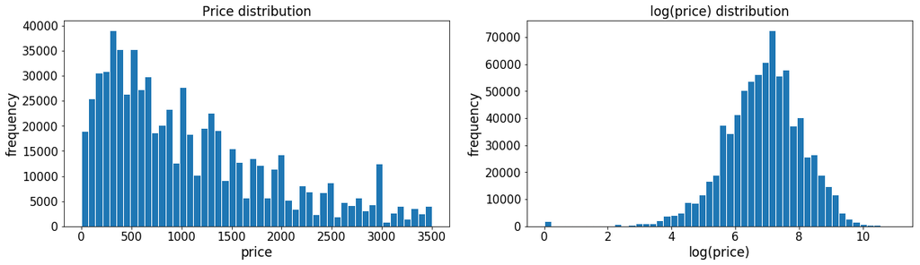

```python
# PLOT: pricing & log(pricing)
plt.subplot(1, 2, 1)
(data['price']).plot.hist(bins=50, figsize=(20,5), edgecolor='white',range=[0,3500])
plt.xlabel('price', fontsize=17)
plt.ylabel('frequency', fontsize=17)
plt.tick_params(labelsize=15)
plt.title('Price distribution', fontsize=17)

plt.subplot(1, 2, 2)
np.log(data['price']).plot.hist(bins=50, figsize=(20,5), edgecolor='white',range=[0,11])
plt.xlabel('log(price)', fontsize=17)
plt.ylabel('frequency', fontsize=17)
plt.tick_params(labelsize=15)
plt.title('log(price) distribution', fontsize=17)
plt.show()
```

```python
# PLOT: Mean price by time
trace1 = _aggregate(data, 'hour', 'price', 'mean', return_trace=True)
trace2 = _aggregate(data, 'day', 'price', 'mean', return_trace=True)
trace3 = _aggregate(data, 'weekday', 'price', 'mean', return_trace=True)
trace4 = _aggregate(data, 'month', 'price', 'mean', return_trace=True)

fig = tools.make_subplots(rows=2, cols=2, print_grid=False,
                          subplot_titles = ['by hour','by day','by weekday','by month'])
fig.append_trace(trace1, 1, 1);
fig.append_trace(trace2, 1, 2);
fig.append_trace(trace3, 2, 1);
fig.append_trace(trace4, 2, 2);

fig['layout'].update(height=400, paper_bgcolor='#f0eff7', plot_bgcolor='#f0eff7', title='Mean Price', showlegend=False);
iplot(fig);
```

[interactive chart not shown]

As observed in the previous plots, the price distribution is positively skewed and is easily fixed with the log() function. Also, we can see that the mean price has little variation by hour, day, weekday or month.

## Step 5: Explore sellers

```python
# DATA SUBSET: Create sellers dataframe

# Seller list
seller_list = data.sellerid.unique()
# Seller groups by earnings & sells
seller_earn_df = data.copy().groupby(["sellerid"])['earnings'].sum().to_frame('earnings').sort_values(by=['earnings'], ascending=False).reset_index()
seller_earn_month_df = data.copy().groupby(["sellerid","month"])['earnings'].sum().to_frame('earnings').sort_values(by=['month','earnings'], ascending=False).reset_index()
seller_num_df = data.copy().groupby(["sellerid"])['sellerid'].count().sort_values(ascending=False).to_frame('sells').reset_index()
seller_num_month_df = data.copy().groupby(["sellerid","month"])['sellerid'].count().to_frame('sells').sort_values(by=['month','sells'], ascending=False).reset_index()
print("Sum of earnings (dataset): ${:,.2f}.").format(seller_earn_df.values.sum())
# Seller id merged stats
seller_totals_df = pd.merge(seller_earn_df, seller_num_df, on='sellerid').rename(columns={'earnings': 'seller_earns','sells': 'seller_sells'})
seller_monthly_df = pd.merge(seller_earn_month_df, seller_num_month_df, on=['sellerid','month'])
# Best / Worst seller limit
BST_SLLR_RATE = .6
WST_SLLR_RATE = .99

display_side_by_side(seller_totals_df.head(),seller_monthly_df.head())
```

```
Sum of earnings (dataset): $2,419,968,773,969.00.
```

|  | sellerid | seller_earns | seller_sells |
| --- | --- | --- | --- |
| 0 | 120289637 | 96855340.06 | 39164 |
| 1 | 198599376 | 89777427.00 | 11 |
| 2 | 122680960 | 73034513.65 | 28295 |
| 3 | 37133205 | 38400921.00 | 12874 |
| 4 | 39144101 | 30777374.00 | 14370 |

|  | sellerid | month | earnings | sells |
| --- | --- | --- | --- | --- |
| 0 | 120289637 | 12 | 14813278.27 | 4909 |
| 1 | 122680960 | 12 | 8995461.55 | 3928 |
| 2 | 37133205 | 12 | 5758789.00 | 1883 |
| 3 | 46082450 | 12 | 4278958.90 | 3780 |
| 4 | 39144101 | 12 | 3359562.00 | 1608 |

```python
# FEATURE ENG: Add seller stats
data = pd.merge(data, seller_totals_df, on='sellerid')
```

```python
# PLOT: Sellers earnings
trace1 = go.Bar(x=list(seller_earn_df[:80].index), y=list(seller_earn_df[:80].earnings))
trace2 = go.Bar(x=list(seller_num_df[:80].index), y=list(seller_num_df[:80].sells))

fig = tools.make_subplots(rows=2, cols=1, print_grid=False, subplot_titles = ['Earnings','Sells'])
fig.append_trace(trace1, 1, 1);
fig.append_trace(trace2, 2, 1);

fig['layout'].update(height=500,  showlegend=False);
iplot(fig);
```

[interactive chart not shown]

```python
# Number of elements with most earnings
MAX_EARNS_BST = seller_earn_df.earnings.sum()*BST_SLLR_RATE
MAX_EARNS_WST = seller_earn_df.earnings.sum()*WST_SLLR_RATE
sum_earnings = 0
for index, row in seller_earn_df.iterrows():
    sum_earnings += row.earnings
    data.loc[data['sellerid'] == row.sellerid, 'worst_seller'] = False
    if sum_earnings < MAX_EARNS_BST:
        data.loc[data['sellerid'] == row.sellerid, 'best_seller'] = True
    if sum_earnings > MAX_EARNS_WST:
        print("Worst sellers (earnings): %d / %d." % (index, len(seller_earn_df.index) ))
        break
# Number of elements with most sells
MAX_SELLS_BST = seller_num_df.sells.sum()*BST_SLLR_RATE
MAX_SELLS_WST = seller_num_df.sells.sum()*WST_SLLR_RATE
sum_sells = 0
for index, row in seller_num_df.iterrows():
    sum_sells += row.sells
    data.loc[data['sellerid'] == row.sellerid, 'worst_seller'] = False
    if sum_sells < MAX_SELLS_BST:
        data.loc[data['sellerid'] == row.sellerid, 'best_seller'] = True
    if sum_sells > MAX_SELLS_WST:
        print("Worst sellers (Number of sells): %d / %d." % (index, len(seller_num_df.index) ))
        break

del MAX_EARNS_BST, MAX_EARNS_WST, sum_earnings, MAX_SELLS_BST, MAX_SELLS_WST, sum_sells
```

```
Worst sellers (earnings): 7615 / 18038.
Worst sellers (Number of sells): 11098 / 18038.
```

```python
# Number of elements with most earnings per month
pie_values = [[None,None]] * 12
for month in range (1,13):
    month_df = seller_earn_month_df[seller_earn_month_df.month == month]
    MAX_EARNS = month_df.earnings.sum()*BST_SLLR_RATE
    sum_earnings = 0
    index_75 = 0
    for index, row in month_df.iterrows():
        data.loc[data['sellerid'] == row.sellerid, 'best_seller'] = True
        sum_earnings += row.earnings
        index_75 += 1
        if sum_earnings > MAX_EARNS:
            pie_values[month-1] = [index_75,len(month_df.index)-index_75]
            break
# Number of elements with most sells per month
monthly_sum = seller_num_month_df.groupby(["month"]).sum().sells
for month in range (1,13):
    MAX_SELLS = monthly_sum.iloc[month-1]*BST_SLLR_RATE
    sum_sells = 0
    for index, row in seller_num_month_df[seller_num_month_df.month == month].iterrows():
        data.loc[data['sellerid'] == row.sellerid, 'best_seller'] = True
        sum_sells += row.sells
        if sum_sells > MAX_SELLS:
            break

del month_df, MAX_EARNS, sum_earnings, index_75, monthly_sum, MAX_SELLS, sum_sells
```

```python
# FEATURE ENG: Remove worst sellers from the dataset
print data.worst_seller.value_counts()
data = data[data.worst_seller != True]
```

```
False    788642
True       6653
Name: worst_seller, dtype: int64
```

```python
# PLOT: 75% of the total earnings by month
labels=['Best sellers','Others']

trace1 = go.Pie(labels=labels, values=pie_values[0],   domain=dict(y=[0,0.5],   x=[0,0.16]))
trace2 = go.Pie(labels=labels, values=pie_values[1],   domain=dict(y=[0.5,1.0], x=[0,0.16]))
trace3 = go.Pie(labels=labels, values=pie_values[2],   domain=dict(y=[0,0.5],   x=[0.16,0.33]))
trace4 = go.Pie(labels=labels, values=pie_values[3],   domain=dict(y=[0.5,1.0], x=[0.16,0.33]))
trace5 = go.Pie(labels=labels, values=pie_values[4],   domain=dict(y=[0,0.5],   x=[0.33,0.5]))
trace6 = go.Pie(labels=labels, values=pie_values[5],   domain=dict(y=[0.5,1.0], x=[0.336,0.5]))
trace7 = go.Pie(labels=labels, values=pie_values[6],   domain=dict(y=[0,0.5],   x=[0.5,0.66]))
trace8 = go.Pie(labels=labels, values=pie_values[7],   domain=dict(y=[0.5,1.0], x=[0.5,0.66]))
trace9 = go.Pie(labels=labels, values=pie_values[8],   domain=dict(y=[0,0.5],   x=[0.66,0.83]))
trace10 = go.Pie(labels=labels, values=pie_values[9],  domain=dict(y=[0.5,1.0], x=[0.66,0.83]))
trace11 = go.Pie(labels=labels, values=pie_values[10], domain=dict(y=[0,0.5],   x=[0.83,1.0]))
trace12 = go.Pie(labels=labels, values=pie_values[11], domain=dict(y=[0.5,1.0], x=[0.83,1.0]))

pie_data = [trace1,trace2,trace3,trace4,trace5,trace6,trace7,trace8,trace9,trace10,trace11,trace12]
layout = go.Layout(title ='Most of the total earnings by month')
fig = go.Figure(data=pie_data,layout=layout)
iplot(fig)

del seller_earn_df, seller_earn_month_df
```

[interactive chart not shown]

## Step 6: Explore Position

```python
# PLOT: Position
trace1 = _generate_bar_plot_ver(data, 'pos', "Position", '#f7a92c', 700, 400, 200, limit=1000, need_trace = True)
fig = tools.make_subplots(rows=1, cols=1, print_grid=False)
fig.append_trace(trace1, 1, 1);
fig['layout'].update(height=300, title='Position', showlegend=False);

iplot(fig);
print("Null values = %d" % data.pos.isnull().sum(axis = 0))
print("Mean = %d" % data.pos.mean())
print("Std = %d" % data.pos.std())
```

[interactive chart not shown]

```
Null values = 939
Mean = 938
Std = 2946
```

```python
# FEATURE ENG: Fill NA values in position
data.fillna(np.rint(data.pos.mean()/3), inplace=True)
```

```python
# PLOT: Sells & Mean Price by Position
trace1 = _generate_bar_plot_ver(data, 'pos', "Positions", '#f7a92c', 700, 400, 200, limit=np.rint(data.pos.mean()), need_trace = True)
trace2 = _aggregate(data, 'pos', 'price', 'mean', return_trace=True)

fig = tools.make_subplots(rows=1, cols=2, print_grid=False, subplot_titles = ['Sells by position','Mean Price by position'])
fig.append_trace(trace1, 1, 1);
fig.append_trace(trace2, 1, 2);

fig['layout'].update(height=400, paper_bgcolor='#f0eff7', plot_bgcolor='#f0eff7', showlegend=False);

iplot(fig);
```

[interactive chart not shown]

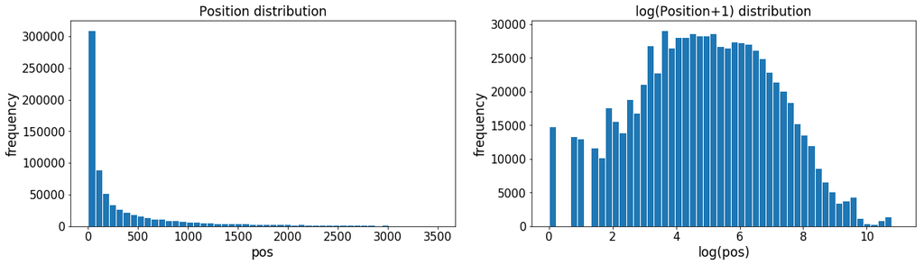

```python
# PLOT: pricing & log(pos)
plt.subplot(1, 2, 1)
(data['pos']).plot.hist(bins=50, figsize=(20,5), edgecolor='white',range=[0,3500])
plt.xlabel('pos', fontsize=17)
plt.ylabel('frequency', fontsize=17)
plt.tick_params(labelsize=15)
plt.title('Position distribution', fontsize=17)

plt.subplot(1, 2, 2)
np.log(data['pos']+1).plot.hist(bins=50, figsize=(20,5), edgecolor='white',range=[0,11])
plt.xlabel('log(pos)', fontsize=17)
plt.ylabel('frequency', fontsize=17)
plt.tick_params(labelsize=15)
plt.title('log(Position+1) distribution', fontsize=17)
plt.show()
```

## Step 7: Explore Title (text processing)

```python
# Title unique values
print("title: %d unique values out of %d." % (data['title'].nunique(), len(data.index)))
```

```
title: 73191 unique values out of 788642.
```

```python
# PLOT: Title lengths
trace1 = _generate_bar_plot_ver(data, 'title_len', "Title Length", '#f7a92c', 700, 400, 200, limit=30, need_trace = True)
fig = tools.make_subplots(rows=1, cols=1, print_grid=False)
fig.append_trace(trace1, 1, 1);
fig['layout'].update(height=300, title='Title word count', showlegend=False);

iplot(fig);
```

[interactive chart not shown]

```python
# Tokenize title
stop = set(stopwords.words('spanish'))
def tokenize(text):
    try:
        regex = re.compile('[' +re.escape(string.punctuation) + '0-9\\r\\t\\n]')
        text = regex.sub(" ", text) # remove punctuation
        tokens_ = [word_tokenize(s) for s in sent_tokenize(text)]
        tokens = []
        for token_by_sent in tokens_:
            tokens += token_by_sent
        tokens = list(filter(lambda t: t.lower() not in stop, tokens))
        filtered_tokens = [w for w in tokens if re.search('[a-zA-Z]', w)]
        filtered_tokens = [w.lower() for w in filtered_tokens if len(w)>=3]
        return filtered_tokens
    except TypeError as e: print(text,e)

data['tokens'] = data['title'].map(tokenize)
data.reset_index(drop=True, inplace=True)
```

```python
# TABLE: Tokenize title stats
for description, tokens in zip(data['title'].head(3),
                              data['tokens'].head(3)):
    print('title:', description)
    print('tokens:', tokens)
    print()
# data.drop(['title'], axis = 1, inplace = True)
```

```
('title:', 'Oximetro De Pulso Saturometro Digital Con Curva - Importado')
('tokens:', ['oximetro', 'pulso', 'saturometro', 'digital', 'curva', 'importado'])
()
('title:', 'Oximetro De Pulso Saturometro Digital Con Curva - Importado')
('tokens:', ['oximetro', 'pulso', 'saturometro', 'digital', 'curva', 'importado'])
()
('title:', 'Oximetro De Pulso Saturometro Digital - Con Curva - Dedo')
('tokens:', ['oximetro', 'pulso', 'saturometro', 'digital', 'curva', 'dedo'])
()
```

```
Text(0.5,1,'Worst Sellers')
```

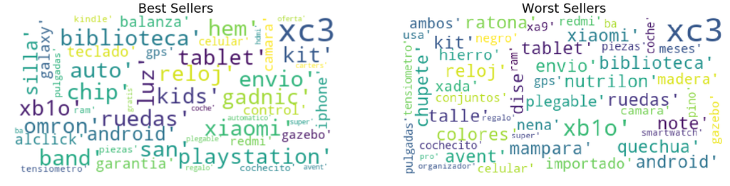

```python
# PLOT: Generate WordCloud
def generate_wordcloud(tup):
    wordcloud = WordCloud(background_color='white',
                          max_words=50, max_font_size=40,
                          random_state=42
                         ).generate(str(tup))
    return wordcloud


cat_sllrs = dict()
for best in [True,False]:
    text = " ".join(data.loc[data['best_seller']==best, 'title'].values)
    cat_sllrs[best] = tokenize(text)

best_sellers = Counter(cat_sllrs[True]).most_common(100)
worst_sellers = Counter(cat_sllrs[False]).most_common(100)

fig,axes = plt.subplots(1, 2, figsize=(30, 15))

ax = axes[0]
ax.imshow(generate_wordcloud(best_sellers), interpolation="bilinear")
ax.axis('off')
ax.set_title("Best Sellers", fontsize=30)

ax = axes[1]
ax.imshow(generate_wordcloud(worst_sellers))
ax.axis('off')
ax.set_title("Worst Sellers", fontsize=30)
```

```python
# TABLE: TF-IDF. Term Frequency–inverse Document Frequency
vectorizer = TfidfVectorizer(min_df=10,
                             max_features=180000,
                             tokenizer=tokenize,
                             ngram_range=(1, 2))

vz = vectorizer.fit_transform(list(data['title'].values))

#  create a dictionary mapping the tokens to their tfidf values
tfidf = dict(zip(vectorizer.get_feature_names(), vectorizer.idf_))
tfidf = pd.DataFrame(columns=['tfidf']).from_dict(
                    dict(tfidf), orient='index')
tfidf.columns = ['tfidf']

df1 = tfidf.sort_values(by=['tfidf'], ascending=True).rename(columns={'tfidf': 'More Important'})
df2 = tfidf.sort_values(by=['tfidf'], ascending=False).rename(columns={'tfidf': 'Less Important'})
display_side_by_side(df1.head(10),df2.head(10))
```

|  | More Important |
| --- | --- |
| tablet | 3.128009 |
| android | 3.351174 |
| bebe | 3.911792 |
| silfab | 3.932811 |
| reloj | 4.021527 |
| funda | 4.058936 |
| digital | 4.073879 |
| wifi | 4.232110 |
| inteligente | 4.266088 |
| reloj inteligente | 4.313347 |

|  | Less Important |
| --- | --- |
| nene bodies | 12.180174 |
| ¡¡oferta zona | 12.180174 |
| docente organizador | 12.180174 |
| bebé suela | 12.180174 |
| impermeable rafia | 12.180174 |
| hdr | 12.180174 |
| descartables minnie | 12.180174 |
| mah zonacamstore | 12.180174 |
| nueva joysticks | 12.180174 |
| reloj soporte | 12.180174 |

```python
# FEATURE ENG: Keras Tokenizer for title feature
raw_text = data.title.str.lower()
tok_raw = Tokenizer(num_words=20000,
                    filters='!"#$%&()*+,-./:;<=>?@[\\]^_`{|}~\t\n',
                    lower=True,
                    split=" ",
                    char_level=False)
tok_raw.fit_on_texts(raw_text)
data["seq_title"] = tok_raw.texts_to_sequences(data.title.str.lower())

del raw_text, tok_raw
```

## Step 8: Label Encoder

```python
# FEATURE ENG: LabelEncoder for state_city feature
le = LabelEncoder()
le.fit(data.state_city)
data['state_city'] = le.transform(data.state_city)

display(le.classes_)
del le
```

```
array(['Buenos Aires / .', 'Buenos Aires / 3 de febrero - Villa Bosch',
       'Buenos Aires / 9 de Julio', ..., 'Tucum\xc3\xa1n / capital',
       'Tucum\xc3\xa1n / concepci\xc3\xb3n', 'Tucum\xc3\xa1n / tucuman'],
      dtype=object)
```

```python
display(data.head(3))
```

|  | title | sellerid | state | city | pos | sqty | price | created_at | weekday | month | ... | weekday_en | title_len | earnings | state_city | best_seller | worst_seller | seller_earns | seller_sells | tokens | seq_title |
| --- | --- | --- | --- | --- | --- | --- | --- | --- | --- | --- | --- | --- | --- | --- | --- | --- | --- | --- | --- | --- | --- |
| 0 | Oximetro De Pulso Saturometro Digital Con Curv... | 99179853 | Capital Federal | CABA | 313.0 | 1 | 799.99 | 2017-03-17 16:07:13 | 4 | 3 | ... | Thu | 9 | 799.99 | 1038 | True | False | 339084.73 | 491 | [oximetro, pulso, saturometro, digital, curva,... | [41, 1, 57, 59, 18, 4, 159, 224] |
| 1 | Oximetro De Pulso Saturometro Digital Con Curv... | 99179853 | Capital Federal | CABA | 313.0 | 1 | 799.99 | 2017-03-17 16:52:10 | 4 | 3 | ... | Thu | 9 | 799.99 | 1038 | True | False | 339084.73 | 491 | [oximetro, pulso, saturometro, digital, curva,... | [41, 1, 57, 59, 18, 4, 159, 224] |
| 2 | Oximetro De Pulso Saturometro Digital - Con Cu... | 99179853 | Capital Federal | CABA | 313.0 | 1 | 799.99 | 2017-03-17 18:00:07 | 4 | 3 | ... | Thu | 10 | 799.99 | 1038 | True | False | 339084.73 | 491 | [oximetro, pulso, saturometro, digital, curva,... | [41, 1, 57, 59, 18, 4, 159, 940] |

3 rows × 23 columns

## Step 9: Transforming Skewed Data

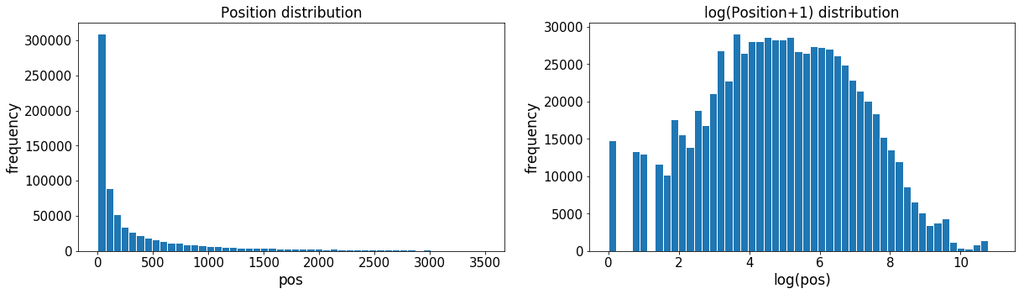

```python
# PLOT: pricing & log(pos)
plt.subplot(1, 2, 1)
(data['pos']).plot.hist(bins=50, figsize=(20,5), edgecolor='white',range=[0,3500])
plt.xlabel('pos', fontsize=17)
plt.ylabel('frequency', fontsize=17)
plt.tick_params(labelsize=15)
plt.title('Position distribution', fontsize=17)

plt.subplot(1, 2, 2)
np.log(data['pos']+1).plot.hist(bins=50, figsize=(20,5), edgecolor='white',range=[0,11])
plt.xlabel('log(pos)', fontsize=17)
plt.ylabel('frequency', fontsize=17)
plt.tick_params(labelsize=15)
plt.title('log(Position+1) distribution', fontsize=17)
plt.show()
```

```python
# FEATURE ENG: Transforming Skewed Data
skewed = ['price','pos']
data = pd.DataFrame(data = data)
data[skewed] = data[skewed].apply(lambda x: np.log(x + 1))
```

## Step 10: Correlation in the dataset

```python
# DATA SUBSET: Numerical data for correlation
numerical = ['price','sellerid','pos','sqty','weekday','month','day','week','hour','title_len','earnings']

numerical_data = data.copy()
numerical_data = numerical_data.loc[:,numerical]
```

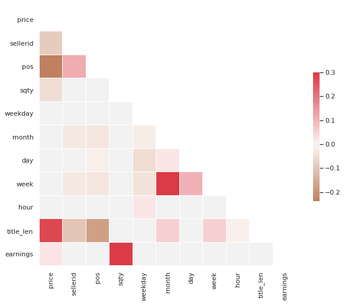

```python
# PLOT: data correlation
corr = numerical_data.corr()
mask = np.zeros_like(corr, dtype=np.bool)
mask[np.triu_indices_from(mask)] = True
sns.set(style="white")

f, ax = plt.subplots(figsize=(10, 8))
cmap = sns.diverging_palette(30, 10, as_cmap=True)
sns.heatmap(corr, mask=mask, cmap=cmap, vmax=.3, center=0, square=True, linewidths=.1, cbar_kws={"shrink": .5});
```

## Step 11: Feature extraction

```python
# SAVE: Final dataset
data.to_csv('database_eng.csv',index=False)
```

```python
# FEATURE ENG: Drop unavailable, irrelevant or highly correlated features
dropable = ['title','sellerid','state','city','created_at','month','weekday_en','earnings','best_seller','worst_seller','seller_earns','seller_sells','tokens']
not_available = ['sqty','pos']
data.drop(dropable+not_available, axis = 1, inplace = True)

del dropable, not_available
```

```python
# SAVE: Final dataset
data.to_csv('database_eng.csv',index=False)
```

```python
# DISPLAY: Final dataset
display(data.head())
```

|  | price | weekday | day | week | hour | title_len | state_city | seq_title |
| --- | --- | --- | --- | --- | --- | --- | --- | --- |
| 0 | 6.685848 | 4 | 17 | 11 | 16 | 9 | 1038 | [41, 1, 57, 59, 18, 4, 159, 224] |
| 1 | 6.685848 | 4 | 17 | 11 | 16 | 9 | 1038 | [41, 1, 57, 59, 18, 4, 159, 224] |
| 2 | 6.685848 | 4 | 17 | 11 | 18 | 10 | 1038 | [41, 1, 57, 59, 18, 4, 159, 940] |
| 3 | 6.685848 | 4 | 17 | 11 | 20 | 9 | 1038 | [41, 1, 57, 59, 18, 4, 159, 224] |
| 4 | 6.685848 | 4 | 17 | 11 | 23 | 10 | 1038 | [41, 1, 57, 59, 18, 4, 159, 940] |